# Wax Lake LISST

Justin Nghiem

9/27/17

*Source files* ⇒ LISST_WaxLake.Rmd ⇒ C:_values.rds

### L1640900 (6/15/17)

Data has been processed to remove samples with optical transmission less than 0.1 or greater than 0.995. The density plots use 9 time groups each spanning a maximum of 60 minutes.

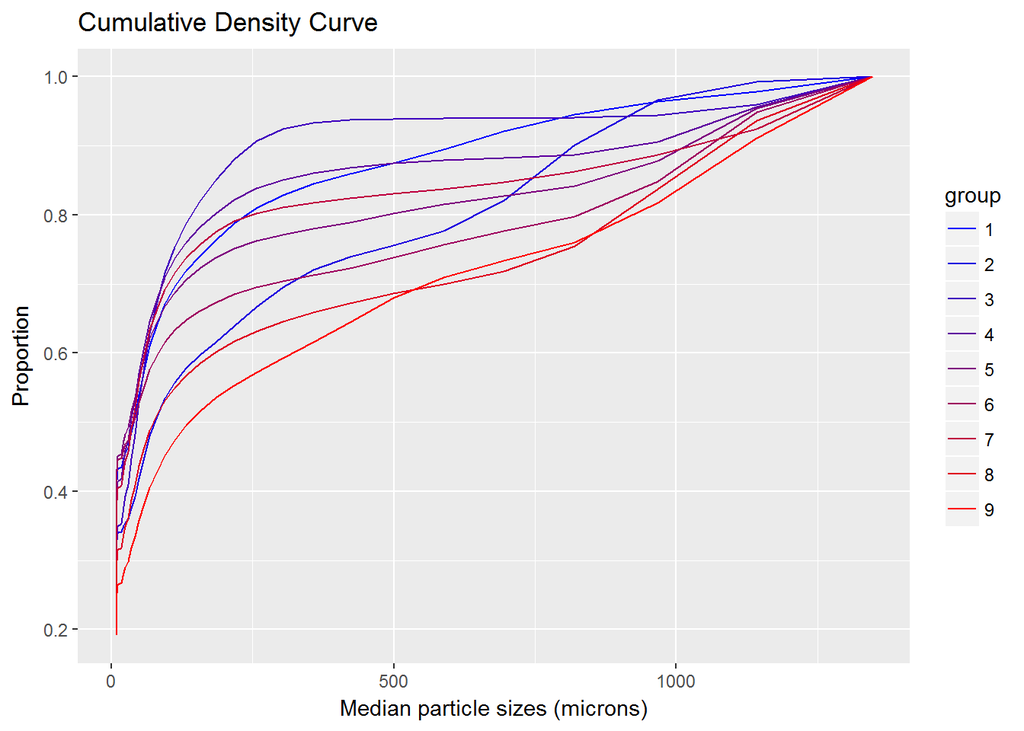

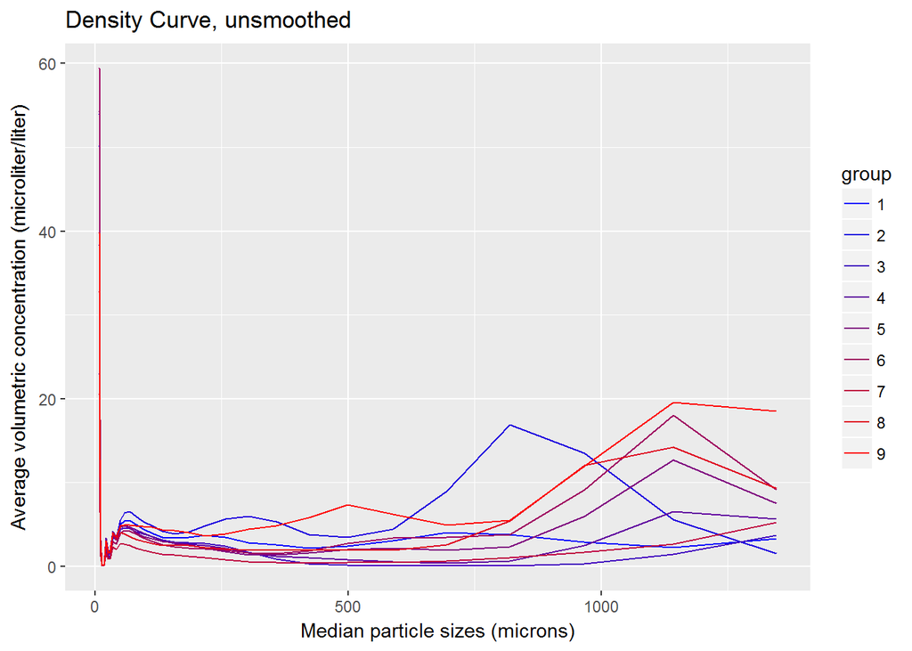

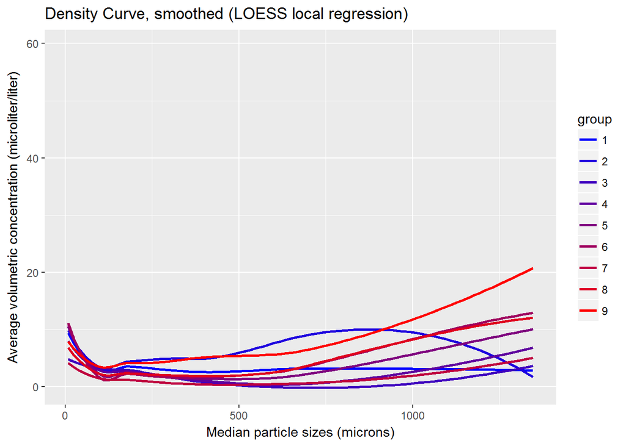

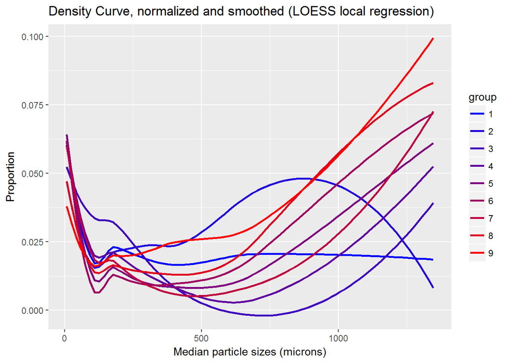

```
## [1] "Number of samples is 3130"
```

| group | avg_size |
| --- | --- |
| 1 | 152.31190 |
| 2 | 145.79018 |
| 3 | 135.76380 |
| 4 | 138.13700 |
| 5 | 149.41934 |
| 6 | 148.79740 |
| 7 | 150.24225 |
| 8 | 142.73078 |
| 16 | 108.33686 |
| 17 | 118.59838 |
| 18 | 93.65962 |
| 19 | 115.13906 |
| 20 | 119.59827 |
| 21 | 123.56287 |
| 22 | 144.32242 |
| 23 | 154.32763 |
| 24 | 194.60355 |
| 25 | 158.26206 |
| 26 | 124.28509 |
| 27 | 136.14278 |
| 28 | 139.81085 |
| 29 | 127.52488 |
| 30 | 155.90953 |
| 31 | 154.24184 |
| 32 | 165.36105 |
| 33 | 275.89171 |
| 34 | 255.29516 |
| 35 | 275.05814 |
| 36 | 283.16974 |
| 37 | 234.46977 |

[output cut: 294 more lines]

`group` denotes the time interval. For example, `group` 1 is the time from the start of the experiment to the end of the first minute in the table above. `avg_size` is the mean particle size in microns. The table above uses 1-minute time intervals. The plot of the table is:

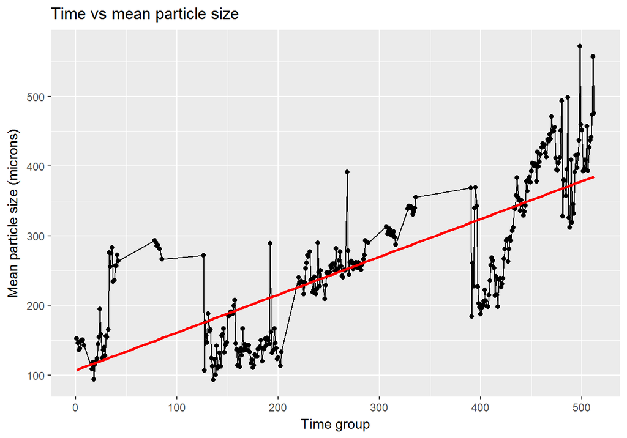

The `mean` of mean particle sizes is 260.6001702. The `standard deviation` of mean particle sizes is 104.8876691. The $R^2$ value is 0.6202389.

### L2061442 (7/25/17)

The data have been processed to remove samples with optical transmission less than 0.1 or greater than 0.995. The density plots use 5-minute intervals.

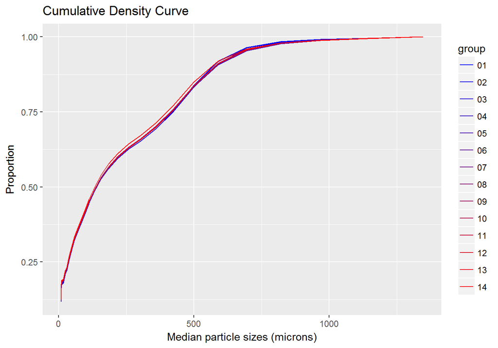

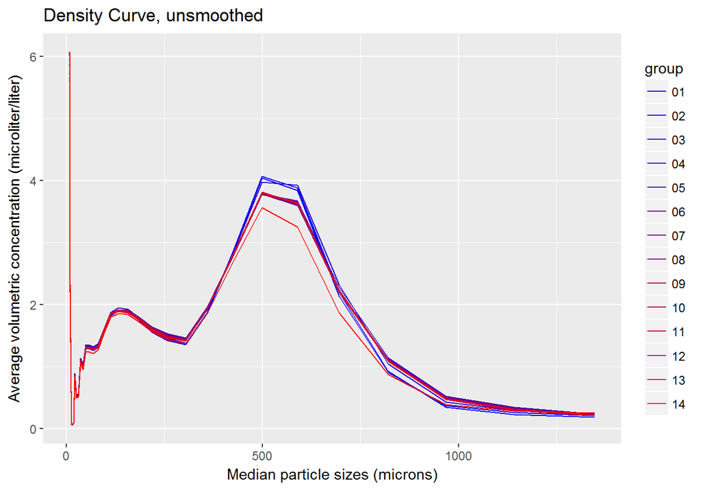

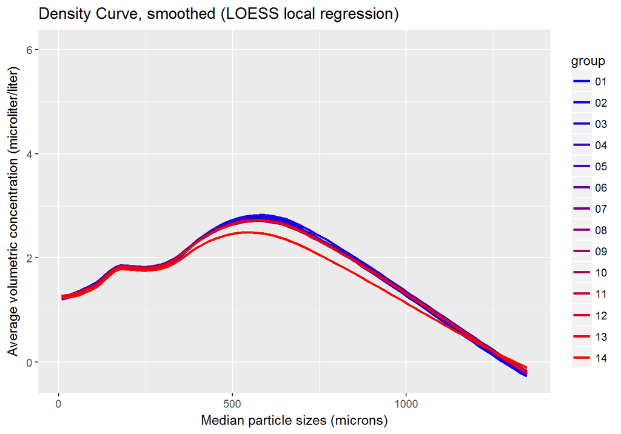

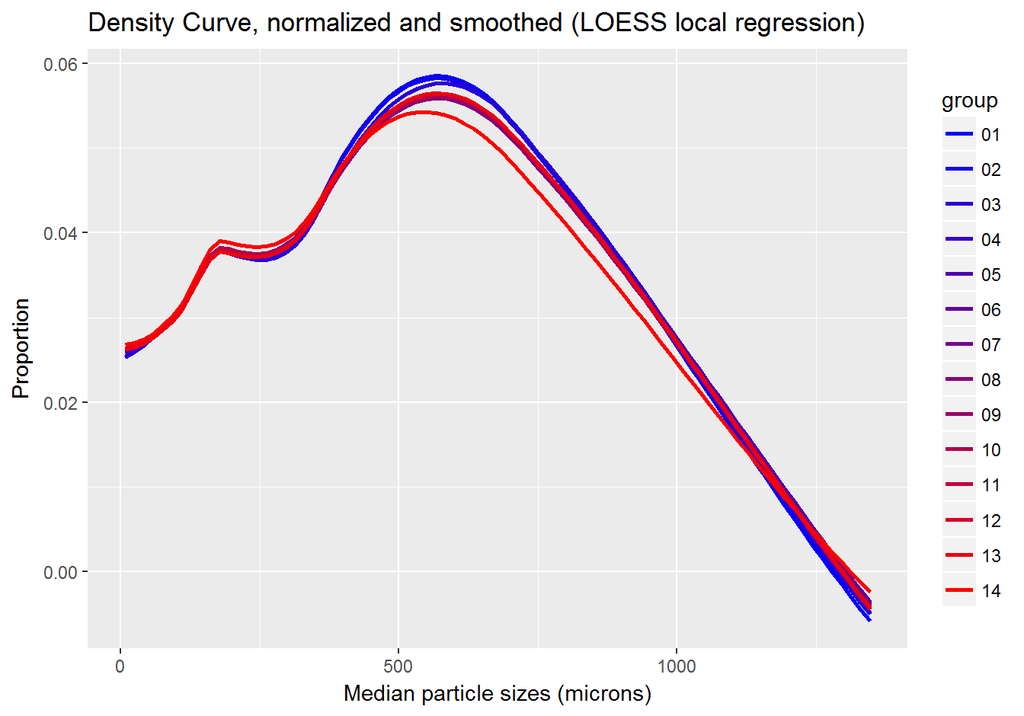

```
## [1] "Number of samples is 3903"
```

| group | avg_size |
| --- | --- |
| 1 | 257.3347 |
| 2 | 254.5308 |
| 3 | 253.0881 |
| 4 | 255.2852 |
| 5 | 257.2255 |
| 6 | 256.1060 |
| 7 | 257.9878 |
| 8 | 256.1981 |
| 9 | 255.4892 |
| 10 | 256.4245 |
| 11 | 257.1241 |
| 12 | 258.0592 |
| 13 | 255.7460 |
| 14 | 260.1799 |
| 15 | 261.1418 |
| 16 | 260.9555 |
| 17 | 257.1354 |
| 18 | 258.9521 |
| 19 | 258.6753 |
| 20 | 257.0747 |
| 21 | 258.6993 |
| 22 | 256.4493 |
| 23 | 257.3751 |
| 24 | 257.5296 |
| 25 | 257.1990 |
| 26 | 258.3781 |
| 27 | 257.3492 |
| 28 | 256.7339 |
| 29 | 256.9657 |
| 30 | 256.6350 |
| 31 | 256.3960 |
| 32 | 255.8900 |
| 33 | 255.8691 |
| 34 | 255.6363 |
| 35 | 255.1800 |
| 36 | 255.8339 |
| 37 | 255.5330 |
| 38 | 255.1244 |
| 39 | 255.3174 |
| 40 | 254.8191 |
| 41 | 255.0821 |
| 42 | 258.8521 |
| 43 | 255.1321 |
| 44 | 256.0239 |
| 45 | 255.4394 |
| 46 | 255.3102 |
| 47 | 256.1559 |
| 48 | 255.6636 |
| 49 | 255.6755 |
| 50 | 256.1389 |
| 51 | 255.7933 |
| 52 | 256.1305 |
| 53 | 256.5930 |
| 54 | 256.4735 |
| 55 | 256.6005 |
| 56 | 256.3175 |
| 57 | 256.4825 |
| 58 | 256.4846 |
| 59 | 256.3402 |
| 60 | 256.9022 |
| 61 | 256.4074 |
| 62 | 256.8192 |
| 63 | 256.5374 |
| 64 | 256.7839 |
| 65 | 256.1781 |
| 66 | 248.8240 |

The table above uses 1-minute timer intervals. The plot of the table is:

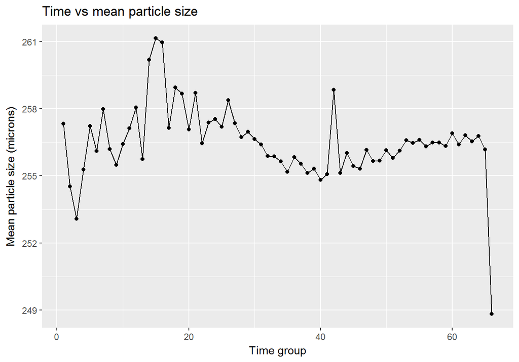

The `mean` of mean particle sizes is 256.4965002. The `standard deviation` of mean particle sizes is 1.7000955.